# IE360-HW2

### IE360 Homework 2

## Ertuğrul Uyar - 2018402063

The aim of the second homework is to forecast the quarterly sales of UGS of 2007.

Installing and calling required packages:

```r
library(xlsx)
library(lubridate)
library(zoo)
library(forecast)
library(dplyr)
library(readxl)
library(data.table)
```

```r
library(ggplot2)
library(RcppRoll)
library(GGally)
library(skimr)
```

Turning the raw data into analysable data:

```r
salesdata=data.table(read.csv("/Users/ertugruluyar/Documents/R /IE360_Spring22_HW2_data.csv",colClasses=c("character", rep("numeric",10))))
colnames(salesdata) <- c("Quarters", "UGS", "RNUV","NLPG","PU","PG","NUGV","NDGV","GNPA","GNPC","GNPT")
salesdata$Quarters <- as.yearqtr(salesdata$Quarters, format = "%Y_Q%q")
str(salesdata)
```

```
## Classes 'data.table' and 'data.frame':   32 obs. of  11 variables:
##  $ Quarters: 'yearqtr' num  2000 Q1 2000 Q2 2000 Q3 2000 Q4 ...
##  $ UGS     : num  1128971 1199569 1370167 1127548 1033918 ...
##  $ RNUV    : num  0.0146 0.0205 0.0207 0.0163 0.0071 0.0051 0.0041 0.0048 0.0012 0.0032 ...
##  $ NLPG    : num  940000 941000 943500 948000 950000 ...
##  $ PU      : num  469 459 440 402 412 ...
##  $ PG      : num  356 345 327 301 306 ...
##  $ NUGV    : num  4647500 4742876 4840931 4919685 4954754 ...
##  $ NDGV    : num  282 284 287 288 288 ...
##  $ GNPA    : num  1040173 1760460 6974808 3267125 1004528 ...
##  $ GNPC    : num  3483132 4525451 5915204 4929778 3418387 ...
##  $ GNPT    : num  18022686 21797130 30050207 24480153 15832648 ...
##  - attr(*, ".internal.selfref")=<externalptr>
```

#1

Time series of UGS:

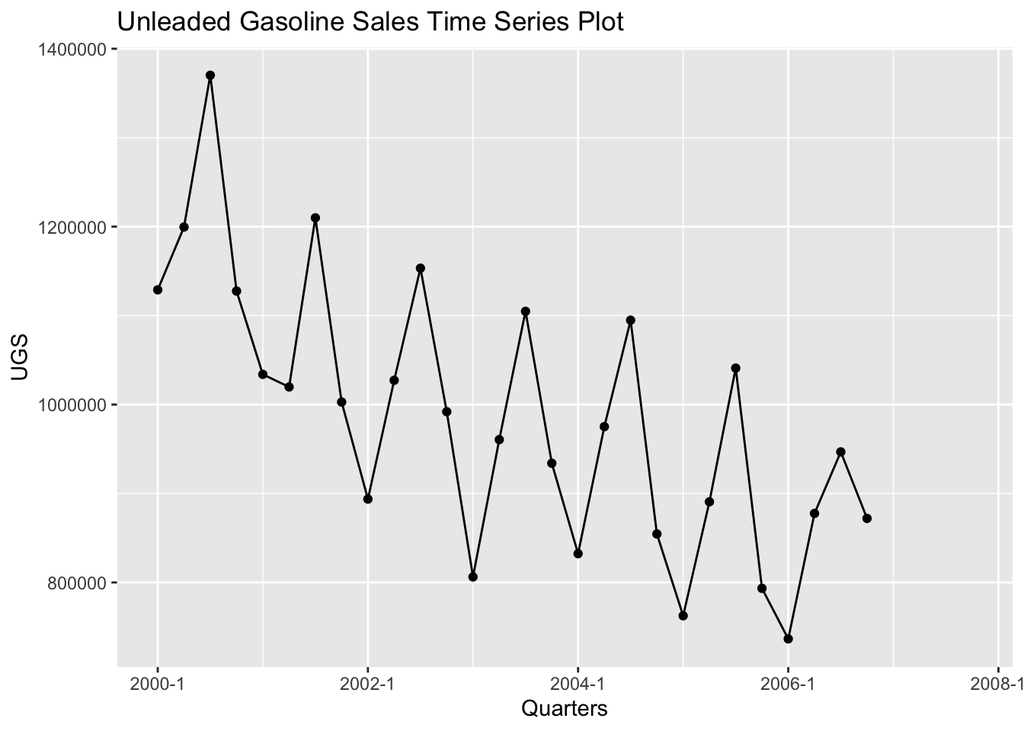

```r
ggplot(salesdata, aes(x=Quarters, y=UGS, group=1)) +
  geom_line()+
  geom_point()+
  ggtitle('Unleaded Gasoline Sales Time Series Plot')
```

As it can be seen, there is a declining trend over the years. In addition, we can see seasonality in such a way that every third quarter has the largest value for thr corresponding year, between almost every 1st and 3rd quarters there is an increase and between every 3rd and 1st quarters there is a decrease.

Mean Series:

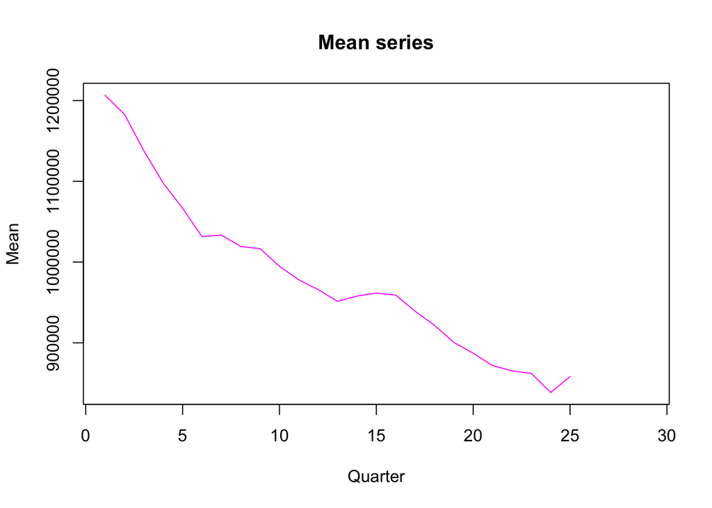

```r
meanUGS=roll_mean(salesdata$UGS,4,align='left')
plot(meanUGS,
     type='l',col='magenta',
     xlab = "Quarter",
     ylab = "Mean",
     main = "Mean series")
```

In terms of mean, as it can be obviously seen from mean series of UGS graph above, observed data is not stationary since there is an obvious trend in the graph.

Variance Series:

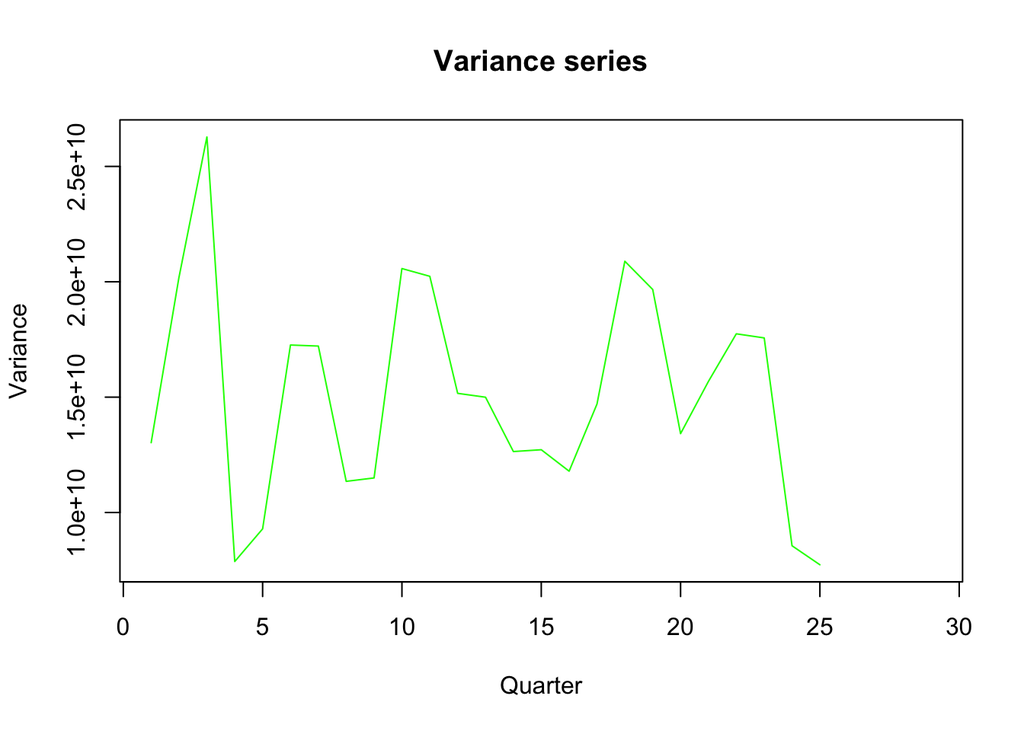

```r
varUGS=roll_var(salesdata$UGS,4,align='left')
plot(varUGS,
     type='l',col='green',
     xlab = "Quarter",
     ylab = "Variance",
     main = "Variance series")
```

Unlike mean series, we cannot deduce stationarity-based observation from variance series of UGS graph above.

#2

Autocorrelation function of the time series of UGS:

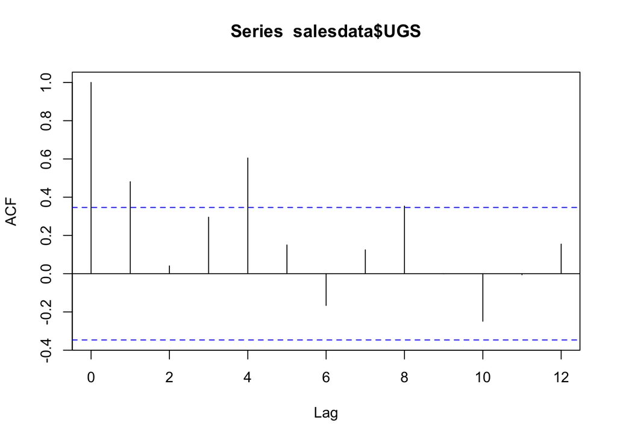

```r
acf(salesdata$UGS,na.action = na.pass,lag.max = 12)
```

By looking at the autocorrelation graph, we can get insigths about whether there is trend and/or seasonality in the data. In that sense, having a high autocorrelation for lag 1 indicates that there can be a trend in the data. On the other hand, having high autocorrelations for lag 4,8 can imply the seasonality, which makes sense since 4 quarters means a year and yearly seasonality is quite reasonable.

#3

Defining trend & lag1 and seasonality & lag4 variables:

```r
salesdata <- salesdata[, trend:=(1:.N)]
salesdata <- salesdata[,Lag1:=c(NA, salesdata$UGS[1:31])]

salesdata <- salesdata[,seasonality:=(1:.N)%%4]
salesdata <- salesdata[seasonality==0,seasonality:=4]
salesdata <- salesdata[,Lag4:=c(rep(NA,4),salesdata$UGS[1:28])]

str(salesdata)
```

```
## Classes 'data.table' and 'data.frame':   32 obs. of  15 variables:
##  $ Quarters   : 'yearqtr' num  2000 Q1 2000 Q2 2000 Q3 2000 Q4 ...
##  $ UGS        : num  1128971 1199569 1370167 1127548 1033918 ...
##  $ RNUV       : num  0.0146 0.0205 0.0207 0.0163 0.0071 0.0051 0.0041 0.0048 0.0012 0.0032 ...
##  $ NLPG       : num  940000 941000 943500 948000 950000 ...
##  $ PU         : num  469 459 440 402 412 ...
##  $ PG         : num  356 345 327 301 306 ...
##  $ NUGV       : num  4647500 4742876 4840931 4919685 4954754 ...
##  $ NDGV       : num  282 284 287 288 288 ...
##  $ GNPA       : num  1040173 1760460 6974808 3267125 1004528 ...
##  $ GNPC       : num  3483132 4525451 5915204 4929778 3418387 ...
##  $ GNPT       : num  18022686 21797130 30050207 24480153 15832648 ...
##  $ trend      : int  1 2 3 4 5 6 7 8 9 10 ...
##  $ Lag1       : num  NA 1128971 1199569 1370167 1127548 ...
##  $ seasonality: num  1 2 3 4 1 2 3 4 1 2 ...
##  $ Lag4       : num  NA NA NA NA 1128971 ...
##  - attr(*, ".internal.selfref")=<externalptr>
##  - attr(*, "index")= int(0)
```

#4

Pairwise correlations of the variables:

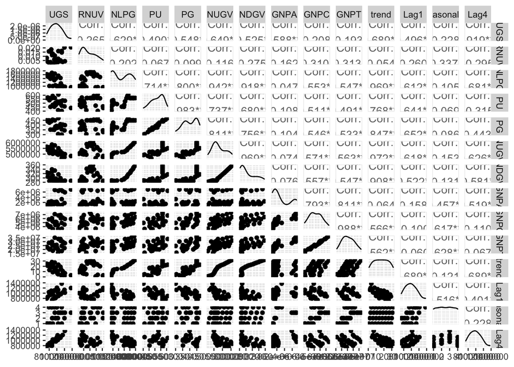

```r
ggpairs(salesdata[,2:15])
```

In order to build models, it makes sense to examine the importance of the coefficients based on their dul correlations. By doing that, it can be seen that UGS is correlated with GNPA, NUGV and NLPG the most. PU, PG and NDGV are also correlated with UGS but not that strong compared to former ones. Therefore, I selected to analyse GNPA, NUGV, NDGV, PG, PU along with trend and seasonality components.

GNPA is added and analysed:

```r
GNPAadded <- lm(UGS~GNPA, salesdata)
summary(GNPAadded)
```

```
##
## Call:
## lm(formula = UGS ~ GNPA, data = salesdata)
##
## Residuals:
##     Min      1Q  Median      3Q     Max
## -193499  -88313  -18851   90094  255627
##
## Coefficients:
##              Estimate Std. Error t value Pr(>|t|)
## (Intercept) 8.754e+05  3.825e+04  22.885  < 2e-16 ***
## GNPA        3.895e-02  1.050e-02   3.708 0.000996 ***
## ---
## Signif. codes:  0 '***' 0.001 '**' 0.01 '*' 0.05 '.' 0.1 ' ' 1
##
## Residual standard error: 124500 on 26 degrees of freedom
##   (4 observations deleted due to missingness)
## Multiple R-squared:  0.3459, Adjusted R-squared:  0.3208
## F-statistic: 13.75 on 1 and 26 DF,  p-value: 0.0009958
```

NUGV is added and analysed:

```r
GNPA_NUGVadded <- lm(UGS~GNPA+NUGV, salesdata)
summary(GNPA_NUGVadded)
```

```
##
## Call:
## lm(formula = UGS ~ GNPA + NUGV, data = salesdata)
##
## Residuals:
##     Min      1Q  Median      3Q     Max
## -131950  -35309   -1196   39606  123585
##
## Coefficients:
##               Estimate Std. Error t value Pr(>|t|)
## (Intercept)  2.657e+06  2.201e+05  12.075 6.28e-12 ***
## GNPA         4.197e-02  5.623e-03   7.464 8.12e-08 ***
## NUGV        -3.442e-01  4.233e-02  -8.132 1.74e-08 ***
## ---
## Signif. codes:  0 '***' 0.001 '**' 0.01 '*' 0.05 '.' 0.1 ' ' 1
##
## Residual standard error: 66490 on 25 degrees of freedom
##   (4 observations deleted due to missingness)
## Multiple R-squared:  0.8206, Adjusted R-squared:  0.8062
## F-statistic: 57.17 on 2 and 25 DF,  p-value: 4.715e-10
```

Since adjusted r-squared value increased significantly, NUGV is an important regressor and added to the model.

NDGV is added and analysed:

```r
GNPA_NUGV_NDGVadded <- lm(UGS~GNPA+NUGV+NDGV, salesdata)
summary(GNPA_NUGV_NDGVadded)
```

```
##
## Call:
## lm(formula = UGS ~ GNPA + NUGV + NDGV, data = salesdata)
##
## Residuals:
##    Min     1Q Median     3Q    Max
## -89620 -47745   7755  34704  87358
##
## Coefficients:
##               Estimate Std. Error t value Pr(>|t|)
## (Intercept)  2.522e+06  1.801e+05  14.005 4.79e-13 ***
## GNPA         4.172e-02  4.513e-03   9.244 2.23e-09 ***
## NUGV        -7.236e-01  1.042e-01  -6.942 3.53e-07 ***
## NDGV         7.066e+03  1.835e+03   3.850 0.000769 ***
## ---
## Signif. codes:  0 '***' 0.001 '**' 0.01 '*' 0.05 '.' 0.1 ' ' 1
##
## Residual standard error: 53360 on 24 degrees of freedom
##   (4 observations deleted due to missingness)
## Multiple R-squared:  0.8891, Adjusted R-squared:  0.8752
## F-statistic: 64.12 on 3 and 24 DF,  p-value: 1.325e-11
```

PG is added and analysed:

```r
GNPA_NUGV_NDGV_PGadded <- lm(UGS~GNPA+NUGV+NDGV+PG, salesdata)
summary(GNPA_NUGV_NDGV_PGadded)
```

```
##
## Call:
## lm(formula = UGS ~ GNPA + NUGV + NDGV + PG, data = salesdata)
##
## Residuals:
##    Min     1Q Median     3Q    Max
## -77051 -45800   5524  40477  85004
##
## Coefficients:
##               Estimate Std. Error t value Pr(>|t|)
## (Intercept)  2.398e+06  2.041e+05  11.750 3.36e-11 ***
## GNPA         4.225e-02  4.485e-03   9.421 2.33e-09 ***
## NUGV        -6.595e-01  1.154e-01  -5.713 8.10e-06 ***
## NDGV         6.947e+03  1.818e+03   3.821 0.000876 ***
## PG          -4.486e+02  3.627e+02  -1.237 0.228723
## ---
## Signif. codes:  0 '***' 0.001 '**' 0.01 '*' 0.05 '.' 0.1 ' ' 1
##
## Residual standard error: 52780 on 23 degrees of freedom
##   (4 observations deleted due to missingness)
## Multiple R-squared:  0.896,  Adjusted R-squared:  0.8779
## F-statistic: 49.53 on 4 and 23 DF,  p-value: 5.617e-11
```

Since there is no significant increase in adjusted r-squared and decrease in p-value, PG can be neglected as a regressor.

PU is added and analysed:

```r
GNPA_NUGV_NDGV_PUadded <- lm(UGS~GNPA+NUGV+NDGV+PU, salesdata)
summary(GNPA_NUGV_NDGV_PUadded)
```

```
##
## Call:
## lm(formula = UGS ~ GNPA + NUGV + NDGV + PU, data = salesdata)
##
## Residuals:
##    Min     1Q Median     3Q    Max
## -79451 -47728   8834  37405  85321
##
## Coefficients:
##               Estimate Std. Error t value Pr(>|t|)
## (Intercept)  2.481e+06  1.872e+05  13.256 2.96e-12 ***
## GNPA         4.209e-02  4.560e-03   9.231 3.38e-09 ***
## NUGV        -6.858e-01  1.138e-01  -6.027 3.81e-06 ***
## NDGV         6.958e+03  1.850e+03   3.760  0.00102 **
## PU          -2.435e+02  2.853e+02  -0.853  0.40231
## ---
## Signif. codes:  0 '***' 0.001 '**' 0.01 '*' 0.05 '.' 0.1 ' ' 1
##
## Residual standard error: 53660 on 23 degrees of freedom
##   (4 observations deleted due to missingness)
## Multiple R-squared:  0.8925, Adjusted R-squared:  0.8738
## F-statistic: 47.73 on 4 and 23 DF,  p-value: 8.199e-11
```

Since there is no significant increase in adjusted r-squared and decrease in p-value, Pu can be neglected as a regressor.

Trend and seasonality variables are combined and analysed:

```r
TrSeasAdded <- lm(UGS ~ trend+seasonality, salesdata)
summary(TrSeasAdded)
```

```
##
## Call:
## lm(formula = UGS ~ trend + seasonality, data = salesdata)
##
## Residuals:
##     Min      1Q  Median      3Q     Max
## -137740  -77142   -5190   74849  205875
##
## Coefficients:
##             Estimate Std. Error t value Pr(>|t|)
## (Intercept)  1073614      55092  19.487  < 2e-16 ***
## trend         -13497       2398  -5.629 7.38e-06 ***
## seasonality    43723      17322   2.524   0.0183 *
## ---
## Signif. codes:  0 '***' 0.001 '**' 0.01 '*' 0.05 '.' 0.1 ' ' 1
##
## Residual standard error: 101500 on 25 degrees of freedom
##   (4 observations deleted due to missingness)
## Multiple R-squared:  0.5819, Adjusted R-squared:  0.5485
## F-statistic:  17.4 on 2 and 25 DF,  p-value: 1.845e-05
```

Having high adjusted r-squared and small p-value, trend and seasonality variables are good to be added to the model as regressors.

Chosen coloumn regressors and trend & seasonality regressors are added and analysed:

```r
Reg_Tr_Seas_Added <- lm(UGS ~ GNPA+NUGV+NDGV+trend+seasonality, salesdata)
summary(Reg_Tr_Seas_Added)
```

```
##
## Call:
## lm(formula = UGS ~ GNPA + NUGV + NDGV + trend + seasonality,
##     data = salesdata)
##
## Residuals:
##    Min     1Q Median     3Q    Max
## -71054 -37897   1192  33312  86526
##
## Coefficients:
##               Estimate Std. Error t value Pr(>|t|)
## (Intercept)  1.668e+06  7.007e+05   2.380  0.02642 *
## GNPA         3.898e-02  4.925e-03   7.915 7.04e-08 ***
## NUGV        -4.755e-01  2.321e-01  -2.049  0.05259 .
## NDGV         5.890e+03  2.075e+03   2.839  0.00955 **
## trend       -7.286e+03  5.697e+03  -1.279  0.21421
## seasonality  1.116e+04  1.031e+04   1.082  0.29076
## ---
## Signif. codes:  0 '***' 0.001 '**' 0.01 '*' 0.05 '.' 0.1 ' ' 1
##
## Residual standard error: 51570 on 22 degrees of freedom
##   (4 observations deleted due to missingness)
## Multiple R-squared:  0.905,  Adjusted R-squared:  0.8834
## F-statistic: 41.93 on 5 and 22 DF,  p-value: 1.594e-10
```

Combination of these regressors gave a good result in terms of adjusted r-squared and p-value; therefore, it is resonable to use them as combined.

Log1 is added and analysed:

```r
Reg_Tr_Seas_Lag1_Added <- lm(UGS ~ GNPA+NUGV+NDGV+trend+seasonality+Lag1, salesdata)
summary(Reg_Tr_Seas_Lag1_Added)
```

```
##
## Call:
## lm(formula = UGS ~ GNPA + NUGV + NDGV + trend + seasonality +
##     Lag1, data = salesdata)
##
## Residuals:
##    Min     1Q Median     3Q    Max
## -44397 -22255  -1188  23930  61870
##
## Coefficients:
##               Estimate Std. Error t value Pr(>|t|)
## (Intercept)  2.654e+06  5.197e+05   5.107 5.37e-05 ***
## GNPA         3.360e-02  3.233e-03  10.391 1.65e-09 ***
## NUGV        -7.909e-01  1.868e-01  -4.234 0.000407 ***
## NDGV         9.736e+03  1.722e+03   5.652 1.57e-05 ***
## trend       -1.113e+04  4.167e+03  -2.671 0.014692 *
## seasonality  5.354e+04  9.850e+03   5.436 2.55e-05 ***
## Lag1        -5.279e-01  9.149e-02  -5.770 1.20e-05 ***
## ---
## Signif. codes:  0 '***' 0.001 '**' 0.01 '*' 0.05 '.' 0.1 ' ' 1
##
## Residual standard error: 32430 on 20 degrees of freedom
##   (5 observations deleted due to missingness)
## Multiple R-squared:  0.9646, Adjusted R-squared:  0.954
## F-statistic: 90.95 on 6 and 20 DF,  p-value: 1.886e-13
```

Lag1 increased the adjusted r-squared value significantly and decreased p-value, meaning that it shoul be added to the model.

Lag4 is added and analysed:

```r
Reg_Tr_Seas_Lags_Added <- lm(UGS ~ GNPA+NUGV+NDGV+trend+seasonality+Lag1+Lag4, salesdata)
summary(Reg_Tr_Seas_Lags_Added)
```

```
##
## Call:
## lm(formula = UGS ~ GNPA + NUGV + NDGV + trend + seasonality +
##     Lag1 + Lag4, data = salesdata)
##
## Residuals:
##    Min     1Q Median     3Q    Max
## -46318 -21130  -1973  20437  67978
##
## Coefficients:
##               Estimate Std. Error t value Pr(>|t|)
## (Intercept)  3.183e+06  9.368e+05   3.397 0.003680 **
## GNPA         3.923e-02  8.981e-03   4.368 0.000478 ***
## NUGV        -9.697e-01  3.954e-01  -2.453 0.026034 *
## NDGV         1.211e+04  4.494e+03   2.695 0.015946 *
## trend       -1.416e+04  6.782e+03  -2.088 0.053153 .
## seasonality  6.367e+04  1.506e+04   4.228 0.000640 ***
## Lag1        -6.358e-01  1.514e-01  -4.200 0.000679 ***
## Lag4        -1.872e-01  2.220e-01  -0.843 0.411654
## ---
## Signif. codes:  0 '***' 0.001 '**' 0.01 '*' 0.05 '.' 0.1 ' ' 1
##
## Residual standard error: 34530 on 16 degrees of freedom
##   (8 observations deleted due to missingness)
## Multiple R-squared:  0.9459, Adjusted R-squared:  0.9222
## F-statistic: 39.94 on 7 and 16 DF,  p-value: 5.787e-09
```

Lag4 decreased the adjusted r-squared value and increased the p-value: therefore, it should not be added to the model as a regressor.

The best model among those tried models are the one with GNPA + NUGV + NDGV + trend + seasonality + Lag1.

```r
finalmodel<- Reg_Tr_Seas_Lag1_Added
summary(finalmodel)
```

```
##
## Call:
## lm(formula = UGS ~ GNPA + NUGV + NDGV + trend + seasonality +
##     Lag1, data = salesdata)
##
## Residuals:
##    Min     1Q Median     3Q    Max
## -44397 -22255  -1188  23930  61870
##
## Coefficients:
##               Estimate Std. Error t value Pr(>|t|)
## (Intercept)  2.654e+06  5.197e+05   5.107 5.37e-05 ***
## GNPA         3.360e-02  3.233e-03  10.391 1.65e-09 ***
## NUGV        -7.909e-01  1.868e-01  -4.234 0.000407 ***
## NDGV         9.736e+03  1.722e+03   5.652 1.57e-05 ***
## trend       -1.113e+04  4.167e+03  -2.671 0.014692 *
## seasonality  5.354e+04  9.850e+03   5.436 2.55e-05 ***
## Lag1        -5.279e-01  9.149e-02  -5.770 1.20e-05 ***
## ---
## Signif. codes:  0 '***' 0.001 '**' 0.01 '*' 0.05 '.' 0.1 ' ' 1
##
## Residual standard error: 32430 on 20 degrees of freedom
##   (5 observations deleted due to missingness)
## Multiple R-squared:  0.9646, Adjusted R-squared:  0.954
## F-statistic: 90.95 on 6 and 20 DF,  p-value: 1.886e-13
```

#5

Validity of our model in term of coefficient significancy is given for each models. It is time to examine residual behaviour.

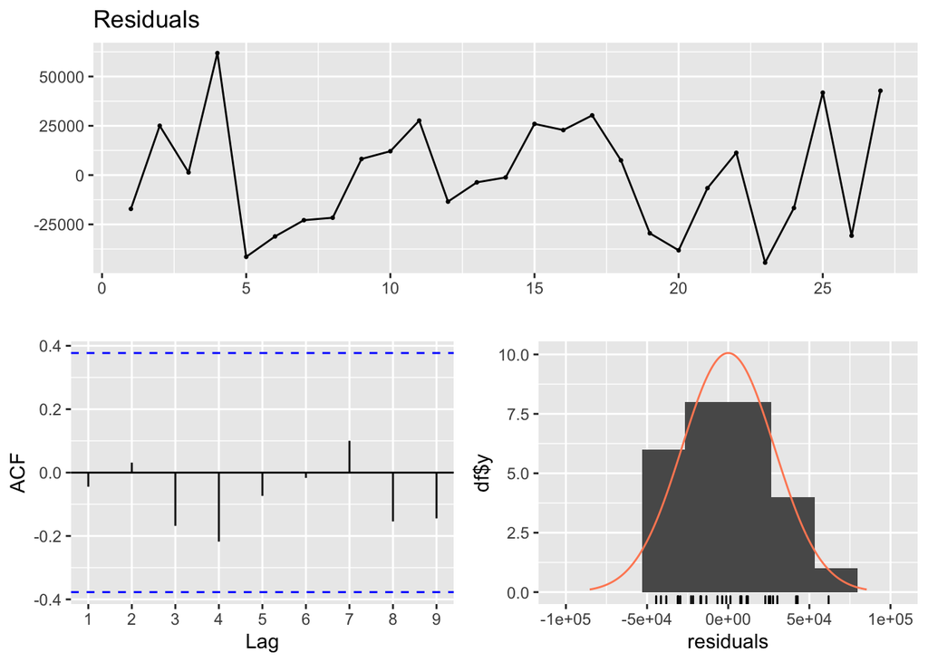

```
##
##  Breusch-Godfrey test for serial correlation of order up to 10
##
## data:  Residuals
## LM test = 11.959, df = 10, p-value = 0.2878
```

```r
checkresiduals(finalmodel)
```

As it can be seen, residuals have negligible amount of autocorrelation and they seem to be normally distributed enough to be OK with that model.

Predicting the 2007 quarterly UGS sales:

```r
to_be_predicted <- salesdata[29:32,c("GNPA","NUGV","NDGV","trend","seasonality","Lag1")]
prediction = c(0,0,0,0)

prediction[1] = predict(finalmodel,newdata = to_be_predicted[1,])
to_be_predicted[2,"Lag1"] = prediction[1]
prediction[2] = predict(finalmodel,newdata = to_be_predicted[2,])
to_be_predicted[3,"Lag1"] = prediction[2]
prediction[3] = predict(finalmodel,newdata = to_be_predicted[3,])
to_be_predicted[4,"Lag1"] = prediction[3]
prediction[4] = predict(finalmodel,newdata = to_be_predicted[4,])
prediction
```

```
## [1] 652169.8 822457.0 958566.2 768598.7
```

Forecasted values for; Q1:652169.8 Q2:822457.0 Q3:958566.2 Q4:768598.7

Real values and predicted values comparison graph:

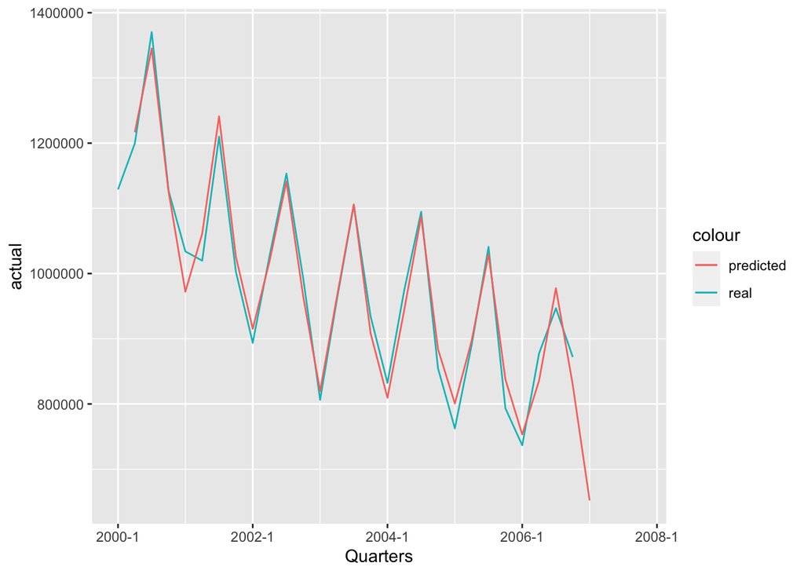

```r
finaldata=copy(salesdata)
finaldata$actual=salesdata$UGS
finaldata$predicted=predict(finalmodel,finaldata)
ggplot(finaldata ,aes(x=Quarters))+
  geom_line(aes(y=actual,color='real')) +
  geom_line(aes(y=predicted,color='predicted'))
```